# Waterlogging microbiome analysis

Hamish McLean

2025-08-07

```r
library(buildmer)
library(car)
library(data.table)
library(DESeq2)
library(dplyr)
library(emmeans)
library(ggpubr)
library(gridExtra)
library(here)
library(kableExtra)
library(lme4)
library(lmPerm)
library(partR2)
library(patchwork)
library(performance)
library(permutes)
library(see)
library(vegan)
library(viridis)
```

```r
here <- here::here()

FUNC_DIR <- here("functions")

source(file.path(FUNC_DIR, "loadme.R"))
source(file.path(FUNC_DIR, "metabarcoding.R"))
source(file.path(FUNC_DIR, "metafuncs.R"))
source(file.path(FUNC_DIR, "rarefaction.R"))
```

```r
DATA_DIR    <- normalizePath(here("..", "Data"))
FIGURES_DIR <- here("figures")

# Bioinformatics pipeline (defaults to DADA2)
# This should be set in the YAML header or passed as a parameter
PIPELINE    <- params$pipeline # DADA2 or USEARCH
ASV_FILTER  <- 0.001 # ASV filter for removing low abundance ASVs
READ_FILTER <- 0.05  # Read count filter for rarefaction
TAX_CONF    <- 0.65  # Confidence threshold for taxonomic rank assignment
SEED        <- 25647 # Random seed

# Colour blind palette
cbPalette <- c(
  "#000000", "#E69F00", "#56B4E9", "#009E73",
  "#F0E442", "#0072B2", "#D55E00", "#CC79A7"
)

# Model designs
# Timepoint model for E1
# formula_t <- y ~ treatment * timepoint + (1 | plot) + (1 | block)
T_DESIGN <- ~ treatment * timepoint + (1 | plot)

# Experiment model without timepoint 2
E_DESIGN <- ~ treatment * experiment + (1 | experiment:block)
```

## 1 Load data

```r
# File extensions based on pipeline
if(PIPELINE == "DADA2") {
  asv_ext <- ".asv_table_filtered.txt"
  fun_tax <- "FUN.sintax.taxa"
  bac_tax <- "BAC.sintax.taxa"
} else if(PIPELINE == "USEARCH") {
  asv_ext <- ".zotu_table.txt"
  fun_tax <- "zFUN.sintax.taxa"
  bac_tax <- "zBAC.sintax.taxa"
} else {
  stop("Pipeline not recognised")
}

# Load fungal data

FUN <- loadData(
  here(DATA_DIR, PIPELINE, paste0("FUN", asv_ext)),
  here(DATA_DIR, "metadata.txt"),
  here(DATA_DIR, PIPELINE, fun_tax),
  tax_conf = TAX_CONF,
  RHB = "FUN"
)

# Load bacterial data

BAC <- loadData(
  here(DATA_DIR, PIPELINE, paste0("BAC", asv_ext)),
  here(DATA_DIR, "metadata.txt"),
  here(DATA_DIR, PIPELINE, bac_tax),
  tax_conf = TAX_CONF,
  RHB = "BAC"
)

# Remove ".raw" from the end of the colnames of the countData
colnames(FUN$countData) <- gsub("\\.raw$", "", colnames(FUN$countData))
colnames(BAC$countData) <- gsub("\\.raw$", "", colnames(BAC$countData))

# Add a new column to colData that combines experiment and timepoint
FUN$colData$exp_tp <- paste(FUN$colData$experiment, FUN$colData$timepoint, sep = "|")
BAC$colData$exp_tp <- paste(BAC$colData$experiment, BAC$colData$timepoint, sep = "|")

# Convert all columns to factors
FUN$colData[] <- lapply(FUN$colData, as.factor)
BAC$colData[] <- lapply(BAC$colData, as.factor)
```

## 2 Filter data

### 2.1 Filter taxa

Plantae taxa are filtered from fungal `taxData`. Chloroplast and Eukaryote taxa are filtered from bacterial `taxData`. Corresponding ASVs are removed from `countData`.

```r
# Fungi: Plantae ASVs
cat(
  "Fungi:\n",
  " - Total ASVs:", nrow(FUN$taxData), "\n",
  " - Plantae ASVs:", length(grep("Plantae", FUN$taxData$kingdom)), "\n\n"
)
```

```
## Fungi:
##   - Total ASVs: 8036
##   - Plantae ASVs: 17
```

```r
# Filter Plantae ASVs
filt <- rownames(FUN$taxData[grep("Plantae", FUN$taxData$kingdom), ])

if(length(filt) == 0) {
  cat("No fungal ASVs to remove\n")
} else {
  cat("Fungi: removing", length(filt), "ASVs\n")
  FUN$taxData <- FUN$taxData[!rownames(FUN$taxData) %in% filt, ]
  FUN$countData <- FUN$countData[!rownames(FUN$countData) %in% filt, ]
}
```

```
## Fungi: removing 17 ASVs
```

```r
# Bacteria: Chloroplast (Streptophyta) and Eukaryote ASVs
cat(
  "Bacteria:\n",
  " - Total ASVs:", nrow(BAC$taxData), "\n",
  " - Chloroplast ASVs:", nrow(BAC$taxData[
    grepl("Streptophyta", BAC$taxData$genus) &
    as.numeric(BAC$taxData$g_conf) >= TAX_CONF,
  ]), "\n",
  " - Eukaryote ASVs:", length(grep("Eukaryota", BAC$taxData$kingdom)), "\n\n"
)
```

```
## Bacteria:
##   - Total ASVs: 84513
##   - Chloroplast ASVs: 16
##   - Eukaryote ASVs: 293
```

```r
# Filter Chloroplast and Eukaryote ASVs
filt <- rownames(
  BAC$taxData[
    grepl("Streptophyta", BAC$taxData$genus) &
    as.numeric(BAC$taxData$g_conf) >= TAX_CONF,
  ]
)

filt <- unique(c(filt, rownames(BAC$taxData[grep("Eukaryota", BAC$taxData$kingdom), ])))

if(length(filt) == 0) {
  cat("No Bacterial ASVs to remove\n")
} else {
  cat("Bacteria: removing", length(filt), "ASVs\n")
  BAC$taxData   <- BAC$taxData[!rownames(BAC$taxData) %in% filt, ]
  BAC$countData <- BAC$countData[!rownames(BAC$countData) %in% filt, ]
}
```

```
## Bacteria: removing 309 ASVs
```

### 2.2 Rarefaction

Remove samples with read count below 5 % of median.

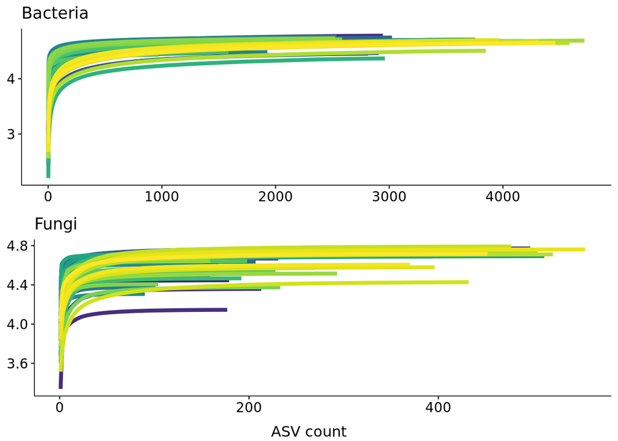

```r
rare_fun <- gfunc(FUN$countData, FUN$colData, "Fungi")

rare_bac <- gfunc(BAC$countData, BAC$colData, "Bacteria")

rarefaction_plots <- grid.arrange(
  rare_bac, rare_fun,
  # left = textGrob(label = expression("log"[10] * " aligned sequences"), rot = 90),
  bottom = "ASV count", nrow = 2
)
```

```r
ggsave(filename = "rarefaction_plots.png", plot = rarefaction_plots, path = FIGURES_DIR)

rarefaction_plots
```

```r
# Fungi
med <- median(colSums(FUN$countData))
filt <- !colSums(FUN$countData) > med * READ_FILTER
cat("Fungi: ", sum(filt), "sample(s) with <", READ_FILTER * 100, "% of median reads\n\n")
```

```
## Fungi:  0 sample(s) with < 5 % of median reads
```

```r
# Bacteria
med <- median(colSums(BAC$countData))
filt <- !colSums(BAC$countData) > med * READ_FILTER
cat("Bacteria: ", sum(filt), "sample(s) with <", READ_FILTER * 100, "% of median reads\n\n")
```

```
## Bacteria:  0 sample(s) with < 5 % of median reads
```

### 2.3 Filter ASVs by read count

Remove ASVs with less than 0.1 % of total reads across all samples.

```r
asv_propotions <- function(countData, proportion){
  i <- sum(countData)
  y <- rowSums(countData)
  y <- y[order(y, decreasing = T)]
  asvs <- length(y[(cumsum(y) / i <= proportion)])
  return(asvs)
}

proportions <- c(0.5, 0.9, 0.99, 0.999, 1)

top_asvs <- data.table(
  "proportion" = proportions,
  "Fungi" = lapply(proportions, function(x) asv_propotions(FUN$countData, x)),
  "Bacteria" = lapply(proportions, function(x) asv_propotions(BAC$countData, x))
)

top_asvs |> kbl()
```

| proportion | Fungi | Bacteria |
| --- | --- | --- |
| 0.500 | 41 | 396 |
| 0.900 | 559 | 11018 |
| 0.990 | 3570 | 71215 |
| 0.999 | 6915 | 81638 |
| 1.000 | 8019 | 84204 |

```r
# top_asvs %>%
#   kbl() %>%
#   kable_styling("striped", full_width = F)
```

Keep only ASVs with at least 10 reads in at least 2 samples.

```r
filter_asvs <- function(countData, min_count = 10, min_samples = 2) {
  keep <- rowSums(countData >= min_count) >= min_samples
  names(keep[keep])
}

# Fungi
# keep <- filter_otus(FUN$countData, ASV_FILTER)
keep <- filter_asvs(FUN$countData)
cat(
  "Fungi:\n",
  " - total ASVs:", nrow(FUN$countData), "\n",
  " - removing", nrow(FUN$countData) - length(keep), "ASVs\n",
  " - remaining ASVs:", length(keep), "\n\n"
)
```

```
## Fungi:
##   - total ASVs: 8019
##   - removing 6795 ASVs
##   - remaining ASVs: 1224
```

```r
FUN$taxData <- FUN$taxData[rownames(FUN$taxData) %in% keep,]
FUN$countData <- FUN$countData[rownames(FUN$countData) %in% keep,]

# Bacteria
# keep <-  filter_asvs(BAC$countData, ASV_FILTER)
keep <- filter_asvs(BAC$countData)
cat(
  "Bacteria:\n",
  " - total ASVs:", nrow(BAC$countData), "\n",
  " - removing", nrow(BAC$countData) - length(keep), "ASVs\n",
  " - remaining ASVs:", length(keep), "\n\n"
)
```

```
## Bacteria:
##   - total ASVs: 84204
##   - removing 79845 ASVs
##   - remaining ASVs: 4359
```

```r
BAC$taxData <- BAC$taxData[rownames(BAC$taxData) %in% keep,]
BAC$countData <- BAC$countData[rownames(BAC$countData) %in% keep,]
```

## 3 Absolute abundance normalisation

ASV normalisation is performed using qPCR theoretical copy number data. Copy number is calculated per mg of root sample from the qPCR data.

### 3.1 Prepare qPCR abundance data

```r
abundance <- read.csv(here(DATA_DIR, "abundance.csv"))

FUN$abundance <- subset(abundance, Target == "ITS")
BAC$abundance <- subset(abundance, Target == "16S")

rownames(FUN$abundance) <- FUN$abundance$Sample
rownames(BAC$abundance) <- BAC$abundance$Sample

# Add `copy_number` to colData from abundance data `TCN_mg`
FUN$colData$copy_number <- FUN$abundance[rownames(FUN$colData), "TCN_mg"]
BAC$colData$copy_number <- BAC$abundance[rownames(BAC$colData), "TCN_mg"]

FUN$colData$log10_copy_number <- log10(FUN$colData$copy_number + 1)
BAC$colData$log10_copy_number <- log10(BAC$colData$copy_number + 1)
```

## 4 Subset data

For both fungi and bacteria: Subset by each question (experiment and timepoint). Subset by each source (root and soil).

```r
FUN_exp <- list(
  root = list(
    countData = FUN$countData[, FUN$colData$source == "root" & FUN$colData$timepoint == 1],
    colData = FUN$colData[FUN$colData$source == "root" & FUN$colData$timepoint == 1, ]
  ),
  soil = list(
    countData = FUN$countData[, FUN$colData$source == "soil" & FUN$colData$timepoint == 1],
    colData = FUN$colData[FUN$colData$source == "soil" & FUN$colData$timepoint == 1, ]
  )
)

FUN_time <- list(
  root = list(
    countData = FUN$countData[, FUN$colData$source == "root" & FUN$colData$experiment == 1],
    colData = FUN$colData[FUN$colData$source == "root" & FUN$colData$experiment == 1, ]
  ),
  soil = list(
    countData = FUN$countData[, FUN$colData$source == "soil" & FUN$colData$experiment == 1],
    colData = FUN$colData[FUN$colData$source == "soil" & FUN$colData$experiment == 1, ]
  )
)

BAC_exp <- list(
  root = list(
    countData = BAC$countData[, BAC$colData$source == "root" & BAC$colData$timepoint == 1],
    colData = BAC$colData[BAC$colData$source == "root" & BAC$colData$timepoint == 1, ]
  ),
  soil = list(
    countData = BAC$countData[, BAC$colData$source == "soil" & BAC$colData$timepoint == 1],
    colData = BAC$colData[BAC$colData$source == "soil" & BAC$colData$timepoint == 1, ]
  )
)

BAC_time <- list(
  root = list(
    countData = BAC$countData[, BAC$colData$source == "root" & BAC$colData$experiment == 1],
    colData = BAC$colData[BAC$colData$source == "root" & BAC$colData$experiment == 1, ]
  ),
  soil = list(
    countData = BAC$countData[, BAC$colData$source == "soil" & BAC$colData$experiment == 1],
    colData = BAC$colData[BAC$colData$source == "soil" & BAC$colData$experiment == 1, ]
  )
)
```

```r
#' Generic iterator function
#' @description Applies a function to each subset of data
#' @param data_list A list of data subsets (e.g., FUN or BAC)
#' @param name A string representing the name of the data (e.g, "Fungi" or "Bacteria")
#' @param func A function to apply to each subset
#' @param ... Additional arguments to pass to the function
#' @return A list of results from applying the function to each subset
#'
apply_to_subsets <- function(data_list, func, name = NULL, ...) {
  # Iterate over sources (root, soil)
  result_list <- lapply(names(data_list), function(source_name) {
    data <- data_list[[source_name]]

    # Apply the provided function to the innermost list element and names
    # Pass the subset data, name, source_name, and any extra args
    if (!is.null(name)) {
      result <- func(data, name, source_name, ...)
    } else {
      result <- func(data, ...)
    }

    # Return the result (assuming func returns the modified list element or results)
    return(result)
  })
  names(result_list) <- names(data_list) # Set names for the result list
  return(result_list)
}
```

```r
# Add taxData
add_taxData <- function(data, taxData) {
  data$taxData <- taxData
  data
}

FUN_exp <- apply_to_subsets(FUN_exp, add_taxData, taxData = FUN$taxData)
BAC_exp <- apply_to_subsets(BAC_exp, add_taxData, taxData = BAC$taxData)

FUN_time <- apply_to_subsets(FUN_time, add_taxData, taxData = FUN$taxData)
BAC_time <- apply_to_subsets(BAC_time, add_taxData, taxData = BAC$taxData)
```

## 5 Create DESeq objects

DESeq2 objects are created for each subset of data.

Absolute abundance normalisation using DESeq2 size factors calculated from qPCR-derived copy number.

Size factor values are centred around the mean of the copy number.

```r
create_dds_subset <- function(data, name, source, design = ~ 1) {
  if(identical(colnames(data$countData), rownames(data$colData))) {

    # Create DESeq object
    dds <- DESeqDataSetFromMatrix(
      countData = data$countData,
      colData = data$colData,
      design = design
    )

    # Set size factors based on copy number
    sizeFactors(dds) <- data$colData$copy_number / mean(data$colData$copy_number)
    # Add dds to data list
    data$dds <- dds
    return(data)

    print(paste0(name, ": ", source, " DESeq object created"))
  } else {
    stop(paste0(name, ": ", source, " countData and colData do not match"))
  }
}

FUN_exp <- apply_to_subsets(FUN_exp, create_dds_subset, "Fungi")
FUN_time <- apply_to_subsets(FUN_time, create_dds_subset, "Fungi")

BAC_exp <- apply_to_subsets(BAC_exp, create_dds_subset, "Bacteria")
BAC_time <- apply_to_subsets(BAC_time, create_dds_subset, "Bacteria")
```

## 6 ASV and sample summary

### 6.1 Read and sample summary

```r
#' @title Read summary
#' @description Create a summary of the read counts per sample
#' @param dds DESeq2 object
#' @param norm Logical, whether to normalise the counts
#' @return A data.table with the total, mean, median, max and min reads per sample
#'
read_summary <- function(dds, norm = FALSE) {
  countData <- counts(dds, normalize = norm)
  data.table(
    "Total reads" = sum(countData),
    "Mean reads per sample" = mean(colSums(countData)),
    "Median reads per sample" = median(colSums(countData)),
    "Max reads per sample" = max(colSums(countData)),
    "Min reads per sample" = min(colSums(countData))
  )
}

print_read_summary <- function(data, title) {
  cat("\n", title, "\n")
  data.table(
    "Metric" = c(
      "Total reads", "Mean reads per sample", "Median reads per sample",
      "Max reads per sample", "Min reads per sample"
    ),
    "Root (Raw)" = unlist(read_summary(data$root$dds, FALSE)),
    "Root (Normalized)" = unlist(read_summary(data$root$dds, TRUE)),
    "Soil (Raw)" = unlist(read_summary(data$soil$dds, FALSE)),
    "Soil (Normalized)" = unlist(read_summary(data$soil$dds, TRUE))
  ) #%>%
    # kbl() %>%
    # kable_styling("striped", full_width = F)
}

print_read_summary(FUN_exp, "Fungi Experiment Read Summary") |> kbl()
```

```
##
##  Fungi Experiment Read Summary
```

| Metric | Root (Raw) | Root (Normalized) | Soil (Raw) | Soil (Normalized) |
| --- | --- | --- | --- | --- |
| Total reads | 553770.0 | 1167538.915 | 899211.00 | 1410272.92 |
| Mean reads per sample | 27688.5 | 58376.946 | 44960.55 | 70513.65 |
| Median reads per sample | 28544.0 | 50598.513 | 48058.00 | 54893.24 |
| Max reads per sample | 43565.0 | 165148.807 | 56554.00 | 159949.10 |
| Min reads per sample | 9937.0 | 1580.884 | 21299.00 | 11011.64 |

```r
print_read_summary(FUN_time, "Fungi Timepoint Read Summary") |> kbl()
```

```
##
##  Fungi Timepoint Read Summary
```

| Metric | Root (Raw) | Root (Normalized) | Soil (Raw) | Soil (Normalized) |
| --- | --- | --- | --- | --- |
| Total reads | 601211.00 | 1231930.739 | 978927.00 | 1786681.15 |
| Mean reads per sample | 30060.55 | 61596.537 | 48946.35 | 89334.06 |
| Median reads per sample | 29770.50 | 43680.542 | 48944.50 | 79047.13 |
| Max reads per sample | 43565.00 | 195610.536 | 56554.00 | 188514.77 |
| Min reads per sample | 9937.00 | 8277.259 | 41378.00 | 15320.97 |

```r
print_read_summary(BAC_exp, "Bacteria Experiment Read Summary") |> kbl()
```

```
##
##  Bacteria Experiment Read Summary
```

| Metric | Root (Raw) | Root (Normalized) | Soil (Raw) | Soil (Normalized) |
| --- | --- | --- | --- | --- |
| Total reads | 831719.00 | 1082906.96 | 728916.0 | 967329.45 |
| Mean reads per sample | 41585.95 | 54145.35 | 36445.8 | 48366.47 |
| Median reads per sample | 41292.50 | 44430.29 | 37430.5 | 42734.96 |
| Max reads per sample | 53442.00 | 187048.18 | 48954.0 | 102297.61 |
| Min reads per sample | 25465.00 | 16407.36 | 23598.0 | 13069.70 |

```r
print_read_summary(BAC_time, "Bacteria Timepoint Read Summary") |> kbl()
```

```
##
##  Bacteria Timepoint Read Summary
```

| Metric | Root (Raw) | Root (Normalized) | Soil (Raw) | Soil (Normalized) |
| --- | --- | --- | --- | --- |
| Total reads | 832341.00 | 1124493.58 | 745293.00 | 1050700.43 |
| Mean reads per sample | 41617.05 | 56224.68 | 37264.65 | 52535.02 |
| Median reads per sample | 40445.00 | 37711.15 | 39069.00 | 44176.12 |
| Max reads per sample | 53442.00 | 183081.50 | 48954.00 | 105747.43 |
| Min reads per sample | 27431.00 | 21622.70 | 18067.00 | 11708.51 |

### 6.2 ASV summary

```r
#' @title ASV summary
#' @description Create a summary of the read counts per ASV
#' @param dds DESeq2 object
#' @param norm Logical, whether to normalise the counts
#' @return A data.table with the total, mean, median, max and min reads per ASV
#'
asv_summary <- function(dds, norm = FALSE) {
  countData <- counts(dds, normalize = norm)
  data.table(
    "Total ASVs" = nrow(countData),
    "Mean reads per ASV" = round(mean(rowSums(countData)), 1),
    "Median reads per ASV" = median(rowSums(countData)),
    "Max reads per ASV" = max(rowSums(countData)),
    "Min reads per ASV" = min(rowSums(countData))
  )
}

print_asv_summary <- function(data, title) {
  cat("\n", title, "\n")
  data.table(
    "Metric" = c(
      "Total ASVs", "Mean reads per ASV", "Median reads per ASV",
      "Max reads per ASV", "Min reads per ASV"
    ),
    "Root (Raw)" = unlist(asv_summary(data$root$dds, FALSE)),
    "Root (Normalized)" = unlist(asv_summary(data$root$dds, TRUE)),
    "Soil (Raw)" = unlist(asv_summary(data$soil$dds, FALSE)),
    "Soil (Normalized)" = round(unlist(asv_summary(data$soil$dds, TRUE)), 2)
  )
}

print_asv_summary(FUN_exp, "Fungi Experiment ASV Summary") |> kbl()


data.table(
  "Metric" = c(
    "Total ASVs", "Mean reads per ASV", "Median reads per ASV",
    "Max reads per ASV", "Min reads per ASV"
  ),
  "Fungi (Raw)" = unlist(asv_summary(FUN$dds, FALSE)),
  "Fungi (Normalized)" = unlist(asv_summary(FUN$dds, TRUE)),
  "Bacteria (Raw)" = unlist(asv_summary(BAC$dds, FALSE)),
  "Bacteria (Normalized)" = round(unlist(asv_summary(BAC$dds, TRUE)), 2)
) %>%
  kbl() %>%
  kable_styling("striped", full_width = F)


top_asvs <- function(countData, taxData, n = 10) {
  y <- rowSums(countData)
  y <- y[order(y, decreasing = T)]
  xy <- y / sum(y)
  data.frame(
    counts = y[1:n],
    proportion = xy[1:n],
    rank = taxData[names(y)[1:n],]$rank
  )
}

top_asvs(FUN$countData, FUN$taxData, n = 10)

top_asvs(counts(BAC$dds, normalize = TRUE), BAC$taxData, n = 10)
```

## 7 Taxonomy Summary

### 7.1 Taxonomy identifiable

Proportion of ASVs which can be assigned (with the given confidence) at each taxonomic rank.

```r
taxonomy_summary <- function(taxData) {
  tx <- copy(taxData)
  setDT(tx)
  cols <- names(taxData)[9:15]
  tx[, (cols) := lapply(.SD, as.numeric), .SDcols = cols]

  data.table(
    rank = c("kingdom", "phylum", "class", "order", "family", "genus", "species"),
    "0.8" = round(unlist(lapply(cols, function(col) sum(tx[[col]] >= 0.8) / nrow(tx))), 2),
    "0.65" = round(unlist(lapply(cols, function(col) sum(tx[[col]] >= 0.65) / nrow(tx))), 2),
    "0.5" = round(unlist(lapply(cols, function(col) sum(tx[[col]] >= 0.5) / nrow(tx))), 2)
  )
}

# Fungi

taxonomy_summary(FUN$taxData) %>%
  kbl() %>%
  kable_styling("striped", full_width = F)
```

| rank | 0.8 | 0.65 | 0.5 |
| --- | --- | --- | --- |
| kingdom | 1.00 | 1.00 | 1.00 |
| phylum | 0.83 | 0.87 | 0.89 |
| class | 0.74 | 0.77 | 0.79 |
| order | 0.61 | 0.66 | 0.67 |
| family | 0.53 | 0.56 | 0.59 |
| genus | 0.44 | 0.50 | 0.54 |
| species | 0.22 | 0.30 | 0.37 |

```r
# Bacteria

taxonomy_summary(BAC$taxData) %>%
  kbl() %>%
  kable_styling("striped", full_width = F)
```

| rank | 0.8 | 0.65 | 0.5 |
| --- | --- | --- | --- |
| kingdom | 1.00 | 1.00 | 1.00 |
| phylum | 0.90 | 0.93 | 0.95 |
| class | 0.79 | 0.84 | 0.88 |
| order | 0.62 | 0.67 | 0.73 |
| family | 0.50 | 0.54 | 0.58 |
| genus | 0.35 | 0.43 | 0.49 |
| species | 0.00 | 0.00 | 0.00 |

Proportion of reads which can be assigned to each taxonomic rank.

```r
taxonomy_summary_reads <- function(taxData, dds) {
  tx <-taxData[rownames(dds), ]
  nc <- counts(dds, normalize = T)
  ac <- sum(nc)
  cols <- names(tx)[9:15]
  # tx[, (cols) := lapply(.SD, as.factor), .SDcols = cols]

  data.table(
    rank = c("kingdom", "phylum", "class", "order", "family", "genus", "species"),
    "0.8" = round(unlist(lapply(cols, function(col) sum(nc[which(as.numeric(tx[[col]]) >= 0.8),]) / ac)), 2),
    "0.65" = round(unlist(lapply(cols, function(col) sum(nc[which(as.numeric(tx[[col]]) >= 0.65),]) / ac)), 2),
    "0.5" = round(unlist(lapply(cols, function(col) sum(nc[which(as.numeric(tx[[col]]) >= 0.5),]) / ac)), 2)
  )
}

# Fungi

# taxonomy_summary_reads(FUN$taxData, FUN$dds) %>%
#   kbl() %>%
#   kable_styling("striped", full_width = F)

# Bacteria

taxonomy_summary_reads(BAC$taxData, BAC$dds) %>%
  kbl() %>%
  kable_styling("striped", full_width = F)
```

### 7.2 Taxonomy plots

## 8 Community size

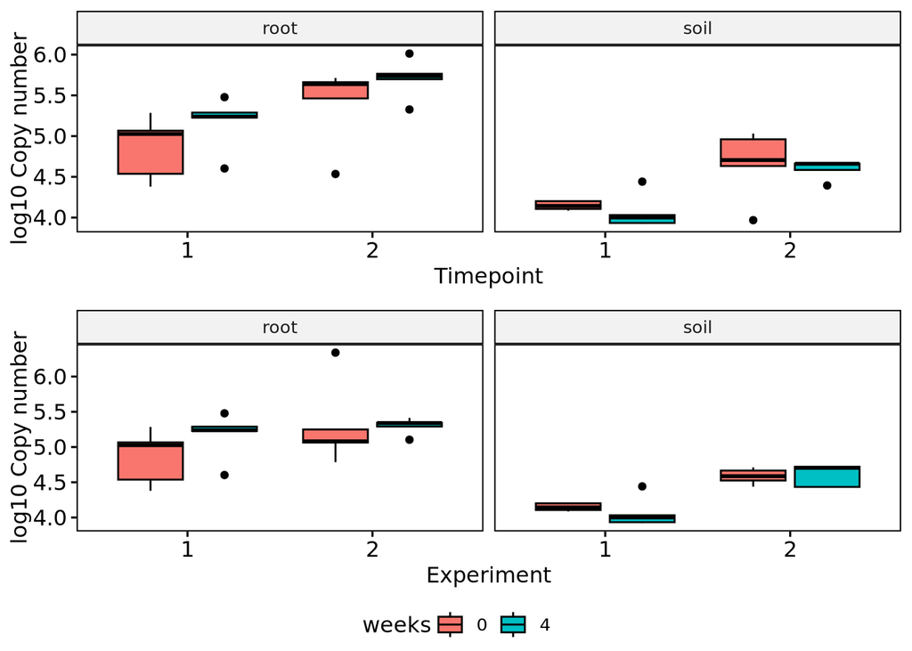

```r
copy_number_combined <- rbind(
  FUN$colData %>% mutate(type = "Fungi"),
  BAC$colData %>% mutate(type = "Bacteria")
)

copy_number_timepoint <- ggboxplot(
  filter(FUN$colData, experiment == 1),
  x = "timepoint", y = "log10_copy_number",
  fill = "weeks",
  xlab = "Timepoint",
  ylab = "log10 Copy number",
  facet.by = c("source")
)

copy_number_experiment <- ggboxplot(
  filter(FUN$colData, timepoint == 1),
  x = "experiment", y = "log10_copy_number",
  fill = "weeks",
  xlab = "Experiment",
  ylab = "log10 Copy number",
  facet.by = c("source")
)

copy_number_plots <- ggarrange(
  copy_number_timepoint,
  copy_number_experiment,
  ncol = 1, nrow = 2,
  common.legend = TRUE, legend = "bottom"
)

ggsave(filename = "FUN_copy_number_plots.png", path = FIGURES_DIR)

copy_number_plots
```

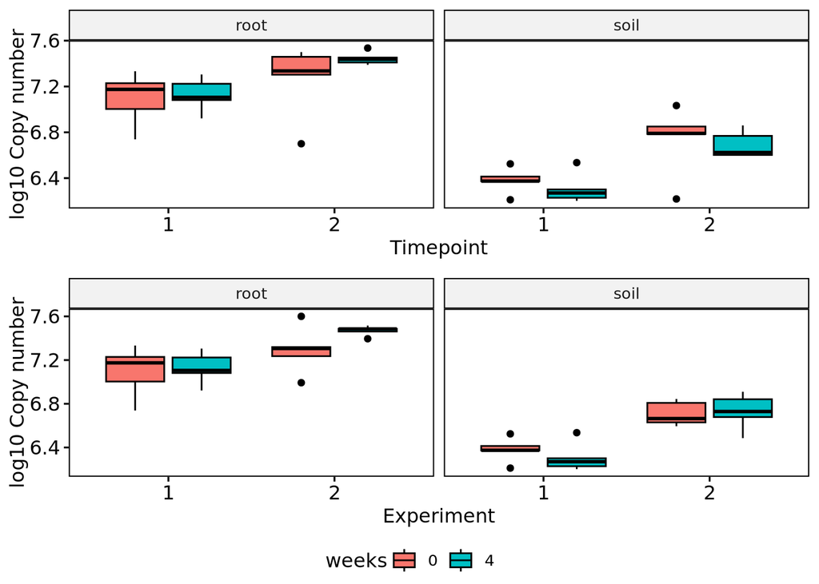

```r
copy_number_timepoint <- ggboxplot(
  filter(BAC$colData, experiment == 1),
  x = "timepoint", y = "log10_copy_number",
  fill = "weeks",
  xlab = "Timepoint",
  ylab = "log10 Copy number",
  facet.by = c("source")
)

copy_number_experiment <- ggboxplot(
  filter(BAC$colData, timepoint == 1),
  x = "experiment", y = "log10_copy_number",
  fill = "weeks",
  xlab = "Experiment",
  ylab = "log10 Copy number",
  facet.by = c("source")
)

ggarrange(
  copy_number_timepoint,
  copy_number_experiment,
  ncol = 1, nrow = 2,
  common.legend = TRUE, legend = "bottom"
)
```

```r
ggsave(filename = "BAC_copy_number_plots.png", path = FIGURES_DIR)
```

```r
copy_number_model <- function(data, name, source, design) {
  cat("\n", name, ":", source, "\n\n")
  model <- lmer(update(design, copy_number ~ .), data$colData)
  # summary(model) |> print()
  Anova(model, type = 3)
}

apply_to_subsets(FUN_exp, copy_number_model, "Fungi Experiment", E_DESIGN)
```

```
##
##  Fungi Experiment : root
##
##
##  Fungi Experiment : soil
```

```
## $root
## Analysis of Deviance Table (Type III Wald chisquare tests)
##
## Response: copy_number
##                       Chisq Df Pr(>Chisq)
## (Intercept)          0.2178  1     0.6407
## treatment            0.0893  1     0.7651
## experiment           2.8478  1     0.0915 .
## treatment:experiment 1.7405  1     0.1871
## ---
## Signif. codes:  0 '***' 0.001 '**' 0.01 '*' 0.05 '.' 0.1 ' ' 1
##
## $soil
## Analysis of Deviance Table (Type III Wald chisquare tests)
##
## Response: copy_number
##                        Chisq Df Pr(>Chisq)
## (Intercept)          11.4085  1  0.0007311 ***
## treatment             0.0335  1  0.8547165
## experiment           18.1929  1  1.996e-05 ***
## treatment:experiment  0.1853  1  0.6668623
## ---
## Signif. codes:  0 '***' 0.001 '**' 0.01 '*' 0.05 '.' 0.1 ' ' 1
```

```r
apply_to_subsets(FUN_time, copy_number_model, "Fungi Timepoint", T_DESIGN)
```

```
##
##  Fungi Timepoint : root
```

```
##
##  Fungi Timepoint : soil
```

```
## $root
## Analysis of Deviance Table (Type III Wald chisquare tests)
##
## Response: copy_number
##                      Chisq Df Pr(>Chisq)
## (Intercept)         1.3082  1    0.25272
## treatment           0.4741  1    0.49111
## timepoint           4.6409  1    0.03122 *
## treatment:timepoint 0.7784  1    0.37762
## ---
## Signif. codes:  0 '***' 0.001 '**' 0.01 '*' 0.05 '.' 0.1 ' ' 1
##
## $soil
## Analysis of Deviance Table (Type III Wald chisquare tests)
##
## Response: copy_number
##                       Chisq Df Pr(>Chisq)
## (Intercept)          2.3499  1  0.1252885
## treatment            0.0069  1  0.9337704
## timepoint           12.5334  1  0.0003997 ***
## treatment:timepoint  1.0471  1  0.3061750
## ---
## Signif. codes:  0 '***' 0.001 '**' 0.01 '*' 0.05 '.' 0.1 ' ' 1
```

```r
apply_to_subsets(BAC_exp, copy_number_model, "Bacteria Experiment", E_DESIGN)
```

```
##
##  Bacteria Experiment : root
```

```
##
##  Bacteria Experiment : soil
```

```
## $root
## Analysis of Deviance Table (Type III Wald chisquare tests)
##
## Response: copy_number
##                        Chisq Df Pr(>Chisq)
## (Intercept)          17.7008  1  2.585e-05 ***
## treatment             0.0023  1   0.961829
## experiment            9.5066  1   0.002047 **
## treatment:experiment  0.6395  1   0.423885
## ---
## Signif. codes:  0 '***' 0.001 '**' 0.01 '*' 0.05 '.' 0.1 ' ' 1
##
## $soil
## Analysis of Deviance Table (Type III Wald chisquare tests)
##
## Response: copy_number
##                        Chisq Df Pr(>Chisq)
## (Intercept)          18.1637  1  2.027e-05 ***
## treatment             0.2003  1  0.6544664
## experiment           11.6701  1  0.0006351 ***
## treatment:experiment  0.4761  1  0.4902062
## ---
## Signif. codes:  0 '***' 0.001 '**' 0.01 '*' 0.05 '.' 0.1 ' ' 1
```

```r
apply_to_subsets(BAC_time, copy_number_model, "Bacteria Timepoint", T_DESIGN)
```

```
##
##  Bacteria Timepoint : root
##
##
##  Bacteria Timepoint : soil
```

```
## $root
## Analysis of Deviance Table (Type III Wald chisquare tests)
##
## Response: copy_number
##                       Chisq Df Pr(>Chisq)
## (Intercept)         21.0173  1  4.552e-06 ***
## treatment            0.0027  1   0.958409
## timepoint            7.6822  1   0.005577 **
## treatment:timepoint  2.6729  1   0.102072
## ---
## Signif. codes:  0 '***' 0.001 '**' 0.01 '*' 0.05 '.' 0.1 ' ' 1
##
## $soil
## Analysis of Deviance Table (Type III Wald chisquare tests)
##
## Response: copy_number
##                       Chisq Df Pr(>Chisq)
## (Intercept)          8.8385  1  0.0029494 **
## treatment            0.0858  1  0.7695999
## timepoint           11.1293  1  0.0008497 ***
## treatment:timepoint  0.3374  1  0.5613278
## ---
## Signif. codes:  0 '***' 0.001 '**' 0.01 '*' 0.05 '.' 0.1 ' ' 1
```

## 9 Alpha diversity

```r
#' @title Calculate alpha diversity
#' @description Calculate alpha diversity metrics for each subset of data
#' @param data A list containing countData and colData
#' @return A list with the alpha diversity data added
#'
calculate_alpha_diversity <- function(data) {
  alpha_dt <- plot_alpha(data$countData, data$colData, returnData = TRUE)
  data$alphaData <- alpha_dt[as.data.table(data$colData, keep.rownames = "Samples"), on = "Samples"]
  return(data)
}

FUN_exp <- apply_to_subsets(FUN_exp, calculate_alpha_diversity)
FUN_time <- apply_to_subsets(FUN_time, calculate_alpha_diversity)
BAC_exp <- apply_to_subsets(BAC_exp, calculate_alpha_diversity)
BAC_time <- apply_to_subsets(BAC_time, calculate_alpha_diversity)
```

```r
#' @title Analyze alpha diversity
#' @description Perform alpha diversity analysis on each subset of data
#' @param data A list containing countData and colData
#' @param name A string representing the name of the data (e.g., "Fungi" or "Bacteria")
#' @param source A string representing the source of the data (e.g., "root" or "soil")
#' @param metrics A vector of alpha diversity metrics to analyze
#' @param formula A formula for the model to use in the analysis
#' @return A list with the alpha diversity results
#'
analyse_alpha_diversity <- function(data, name, source, metrics, formula) {
  cat(paste0("\nAnalyzing alpha diversity for ", name, ":", source, "\n"))

  # Run alpha diversity analysis for each metric
  anova_results <- list()
  for (met in metrics) {
    cat("  - Metric:", met, "\n")
    # Ensure the metric column exists and is numeric before ranking
    if (!met %in% names(data$alphaData)) {
      warning("Metric '", met, "' not found in alpha data for ", name, ": ", source)
      next
    }
    if (!is.numeric(data$alphaData[[met]])) {
      warning("Metric '", met, "' is not numeric in alpha data for ", name, ": ", source, ". Skipping ANOVA.")
      next
    }

    # Create a temporary column for the ranked metric for the model
    temp_dt <- copy(data$alphaData) # Work on a copy to avoid modifying original alpha_dt in place with 'metric' column
    temp_dt[, model_metric := rank(get(met))]
    # Update the formula to use the temporary 'model_metric'
    model_formula <- update(formula, model_metric ~ .)
    # Ensure all variables in the formula exist in the data
    formula_vars <- all.vars(model_formula)
    if (!all(formula_vars %in% names(temp_dt))) {
      missing_vars <- setdiff(formula_vars, names(temp_dt))
      warning("Missing variables in data for ", name, ":", source, ":", paste(missing_vars, collapse = ", "), ". Skipping ANOVA for metric ", met)
      next
    }
    # Run the permutation model
    res <- tryCatch({
      perm.lmer(model_formula, temp_dt, type = "anova", nperm = 1000)
    }, error = function(e) {
      warning("Error running perm.lmer for ", name, ":", source, ", metric ", met, ": ", e$message)
      NULL # Return NULL on error
    })
    if (!is.null(res)) {
      print(res) # Print the ANOVA table
      # print()
      # anova_results[[met]] <- res$anova # Store the result
    } else {
      # anova_results[[met]] <- "Error" # Indicate error
      warning("ANOVA for ", name, ":", source, ", metric ", met, " failed.")
    }
  }
  # Return results (e.g., the alpha data and ANOVA results)
  # return(data$alphaData) # Return the alpha data with metrics
}

# Define metrics
metrics <- c("S.chao1", "shannon", "simpson")

apply_to_subsets(FUN_exp, analyse_alpha_diversity, "Fungi Experiment", metrics, E_DESIGN)
```

```
##
## Analyzing alpha diversity for Fungi Experiment:root
##   - Metric: S.chao1
##                 Factor df        LRT           F     p
## 1          (Intercept)  1 72.4911865 12.07000568    NA
## 2            treatment  1  0.5757634  0.06324111 0.378
## 3           experiment  1  2.2098184  0.03862402 0.166
## 4 treatment:experiment  1  0.2899535  0.03162055 0.556
##   - Metric: shannon
##                 Factor df        LRT          F     p
## 1          (Intercept)  1 39.0685932 9.87654316    NA
## 2            treatment  1  0.1507513 0.02130493 0.612
## 3           experiment  1 15.6066189 1.92901234 0.002
## 4 treatment:experiment  1  0.3003748 0.04260985 0.574
##   - Metric: simpson
##                 Factor df       LRT          F     p
## 1          (Intercept)  1 31.396539 12.8812261    NA
## 2            treatment  1  2.144792  0.4179728 0.161
## 3           experiment  1  8.098849  1.6896552 0.030
## 4 treatment:experiment  1  5.643621  1.2037617 0.014
##
## Analyzing alpha diversity for Fungi Experiment:soil
##   - Metric: S.chao1
##                 Factor df        LRT         F     p
## 1          (Intercept)  1 33.2062003 9.1571906    NA
## 2            treatment  1  0.2781768 0.0430622 0.509
## 3           experiment  1 23.5557853 4.8294314 0.000
## 4 treatment:experiment  1  5.4195386 0.9569378 0.053
##   - Metric: shannon
##                 Factor df       LRT          F     p
## 1          (Intercept)  1 42.930189 19.7802198    NA
## 2            treatment  1  1.995636  0.3472222 0.154
## 3           experiment  1 51.663357 32.0439561 0.000
## 4 treatment:experiment  1  2.520493  0.4444444 0.109
##   - Metric: simpson
##                 Factor df       LRT          F     p
## 1          (Intercept)  1 50.147122 22.3488371    NA
## 2            treatment  1  5.052225  0.8596491 0.056
## 3           experiment  1 57.920674 33.9069765 0.000
## 4 treatment:experiment  1  3.440011  0.5614035 0.064
```

```r
apply_to_subsets(FUN_time, analyse_alpha_diversity, "Fungi Timepoint", metrics, T_DESIGN)
```

```
##
## Analyzing alpha diversity for Fungi Timepoint:root
##   - Metric: S.chao1
##                Factor df         LRT            F     p
## 1         (Intercept)  1 42.87619283 30.127516779    NA
## 2           treatment  1  0.01677149  0.003355705 0.888
## 3           timepoint  1  8.43108442  2.097315436 0.025
## 4 treatment:timepoint  1  0.82180830  0.167785235 0.325
##   - Metric: shannon
##                Factor df        LRT           F     p
## 1         (Intercept)  1 41.3749251 27.65957447    NA
## 2           treatment  1  0.2601663  0.05237316 0.523
## 3           timepoint  1 11.6042243  3.14566285 0.010
## 4 treatment:timepoint  1  0.1305062  0.02618658 0.699
##   - Metric: simpson
##                Factor df        LRT          F     p
## 1         (Intercept)  1 38.1164370 22.8997290    NA
## 2           treatment  1  0.6531737  0.1327913 0.307
## 3           timepoint  1  7.0615539  1.6937669 0.035
## 4 treatment:timepoint  1  1.2856885  0.2655827 0.219
##
## Analyzing alpha diversity for Fungi Timepoint:soil
##   - Metric: S.chao1
##                Factor df        LRT          F     p
## 1         (Intercept)  1 24.5818753 9.13586957    NA
## 2           treatment  1  1.3891286 0.27173913 0.234
## 3           timepoint  1  1.1325123 0.22657343 0.226
## 4 treatment:timepoint  1  0.4551048 0.08951049 0.486
##   - Metric: shannon
##                Factor df       LRT          F     p
## 1         (Intercept)  1 33.280980 14.0969163    NA
## 2           treatment  1  2.057519  0.3568282 0.165
## 3           timepoint  1  6.537038  1.4097561 0.039
## 4 treatment:timepoint  1 11.455629  2.8195122 0.001
##   - Metric: simpson
##                Factor df       LRT          F    p
## 1         (Intercept)  1 44.032851 16.5142857   NA
## 2           treatment  1  2.359002  0.2571429 0.14
## 3           timepoint  1 25.254585  7.6736842 0.00
## 4 treatment:timepoint  1 20.452264  5.3894737 0.00
```

```r
apply_to_subsets(BAC_exp, analyse_alpha_diversity, "Bacteria Experiment", metrics, E_DESIGN)
```

```
##
## Analyzing alpha diversity for Bacteria Experiment:root
##   - Metric: S.chao1
##                 Factor df       LRT          F     p
## 1          (Intercept)  1 59.833400 75.6756757    NA
## 2            treatment  1  4.905806  1.1119691 0.055
## 3           experiment  1 30.388067 14.2779923 0.000
## 4 treatment:experiment  1  1.198861  0.2471042 0.248
##   - Metric: shannon
##                 Factor df       LRT           F     p
## 1          (Intercept)  1 68.848125 109.5200013    NA
## 2            treatment  1  2.539606   0.5157894 0.144
## 3           experiment  1 38.475743  21.1600002 0.000
## 4 treatment:experiment  1  1.694561   0.3368420 0.170
##   - Metric: simpson
##                 Factor df         LRT            F     p
## 1          (Intercept)  1 73.11893851 121.00000020    NA
## 2            treatment  1  0.06349188   0.01146132 0.753
## 3           experiment  1 40.13410495  20.66326534 0.000
## 4 treatment:experiment  1  2.95083941   0.57306589 0.078
##
## Analyzing alpha diversity for Bacteria Experiment:soil
##   - Metric: S.chao1
##                 Factor df        LRT          F     p
## 1          (Intercept)  1 24.5236338 9.63276451    NA
## 2            treatment  1  0.2172459 0.04368601 0.588
## 3           experiment  1  1.8751525 0.39317406 0.170
## 4 treatment:experiment  1  0.6712039 0.13651877 0.395
##   - Metric: shannon
##                 Factor df         LRT            F     p
## 1          (Intercept)  1 32.01025391 10.229854696    NA
## 2            treatment  1  0.02042125  0.003364172 0.850
## 3           experiment  1  2.74488102  0.380449142 0.127
## 4 treatment:experiment  1  0.64335417  0.107653490 0.392
##   - Metric: simpson
##                 Factor df       LRT          F     p
## 1          (Intercept)  1 64.036087 17.0846621    NA
## 2            treatment  1  3.923441  0.5120000 0.092
## 3           experiment  1  6.868487  0.2969325 0.037
## 4 treatment:experiment  1  4.363878  0.5760000 0.049
```

```r
apply_to_subsets(BAC_time, analyse_alpha_diversity, "Bacteria Timepoint", metrics, T_DESIGN)
```

```
##
## Analyzing alpha diversity for Bacteria Timepoint:root
##   - Metric: S.chao1
##                Factor df       LRT         F     p
## 1         (Intercept)  1 65.240783 65.472566    NA
## 2           treatment  1  8.531757  1.387611 0.026
## 3           timepoint  1 26.592040  9.183856 0.000
## 4 treatment:timepoint  1 13.020080  3.031390 0.002
##   - Metric: shannon
##                Factor df       LRT      F     p
## 1         (Intercept)  1 66.913693 109.52    NA
## 2           treatment  1  2.311167   0.49 0.136
## 3           timepoint  1 36.779221  21.16 0.000
## 4 treatment:timepoint  1  1.539221   0.32 0.187
##   - Metric: simpson
##                Factor df        LRT            F     p
## 1         (Intercept)  1 67.9718473 1.156878e+02    NA
## 2           treatment  1  0.0487211 9.756098e-03 0.773
## 3           timepoint  1 37.8004336 2.247805e+01 0.000
## 4 treatment:timepoint  1  0.3864855 7.804878e-02 0.533
##
## Analyzing alpha diversity for Bacteria Timepoint:soil
##   - Metric: S.chao1
##                Factor df        LRT           F     p
## 1         (Intercept)  1 28.5610881 12.68230818    NA
## 2           treatment  1  0.2018945  0.04058339 0.556
## 3           timepoint  1  0.4514298  0.09131262 0.417
## 4 treatment:timepoint  1  1.2057771  0.24857324 0.266
##   - Metric: shannon
##                Factor df        LRT         F     p
## 1         (Intercept)  1 22.9056904 8.5733423    NA
## 2           treatment  1  0.8394675 0.1714668 0.293
## 3           timepoint  1  6.5255576 1.5432016 0.039
## 4 treatment:timepoint  1  1.2715046 0.2625586 0.240
##   - Metric: simpson
##                Factor df       LRT          F     p
## 1         (Intercept)  1 32.931170 16.7563636    NA
## 2           treatment  1  1.421027  0.2945455 0.226
## 3           timepoint  1 13.762693  3.9600000 0.004
## 4 treatment:timepoint  1  6.858895  1.6363636 0.012
```

### 9.1 Alpha diversity plots

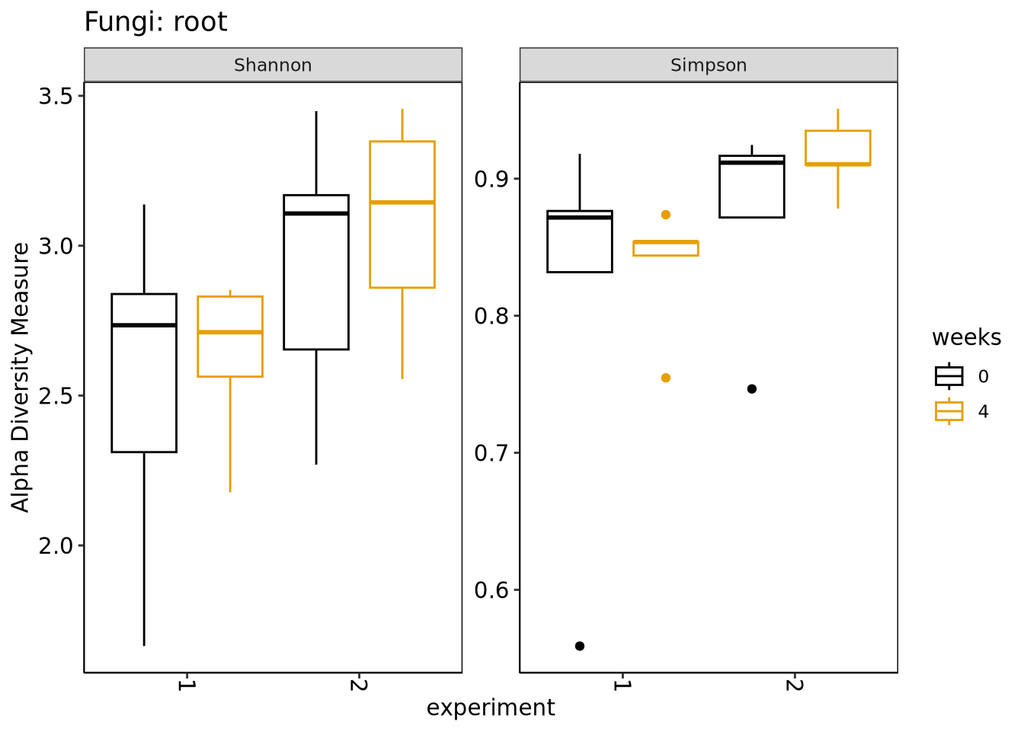

```r
measures <- c("Shannon", "Simpson")

# Root fungi

alpha_FUN_root_exp <- plot_alpha(
  FUN_exp$root$countData, FUN_exp$root$colData,
  design = "experiment", colour = "weeks",
  measures = measures,
  type = "box"
) + scale_colour_manual(values = cbPalette) +
  # theme(axis.title.x = element_blank()) +
  ggtitle("Fungi: root")
alpha_FUN_root_exp
```

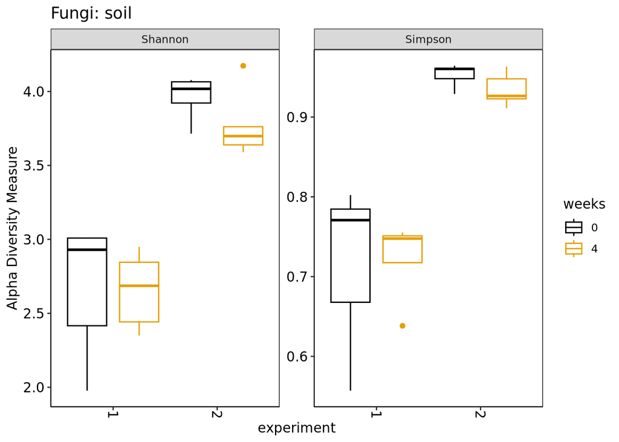

```r
ggsave(filename = "alpha_FUN_root_exp.png", path = FIGURES_DIR)

# Soil fungi

alpha_FUN_soil_exp <- plot_alpha(
  FUN_exp$soil$countData, FUN_exp$soil$colData,
  design = "experiment", colour = "weeks",
  measures = measures,
  type = "box"
) + scale_colour_manual(values = cbPalette) +
  # theme(axis.title.x = element_blank()) +
  ggtitle("Fungi: soil")
alpha_FUN_soil_exp
```

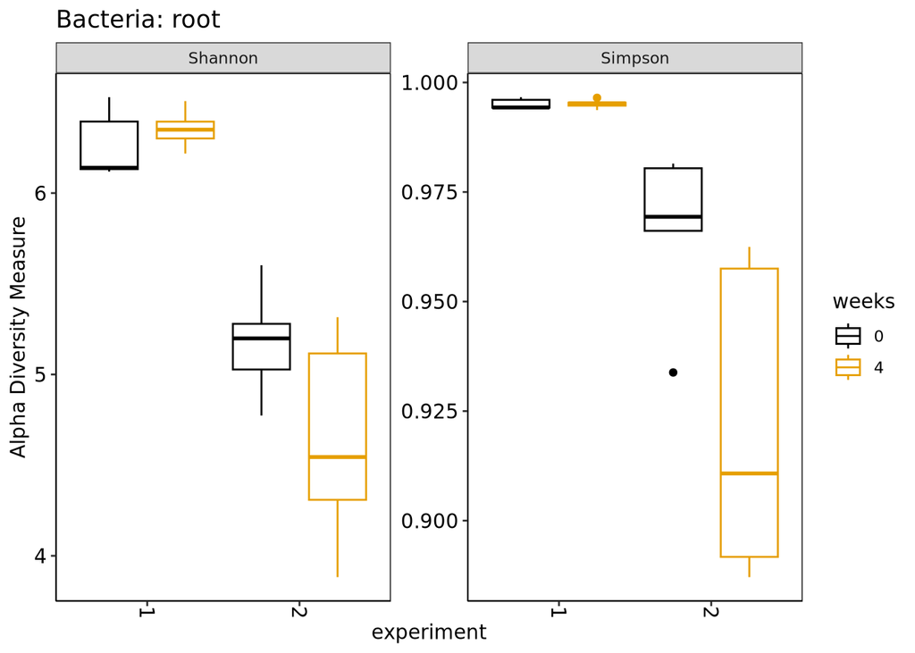

```r
ggsave(filename = "alpha_FUN_soil_exp.png", path = FIGURES_DIR)

# Root bacteria

alpha_BAC_root_exp <- plot_alpha(
  BAC_exp$root$countData, BAC_exp$root$colData,
  design = "experiment", colour = "weeks",
  measures = measures,
  type = "box"
) + scale_colour_manual(values = cbPalette) +
  # theme(axis.title.x = element_blank()) +
  ggtitle("Bacteria: root")
alpha_BAC_root_exp
```

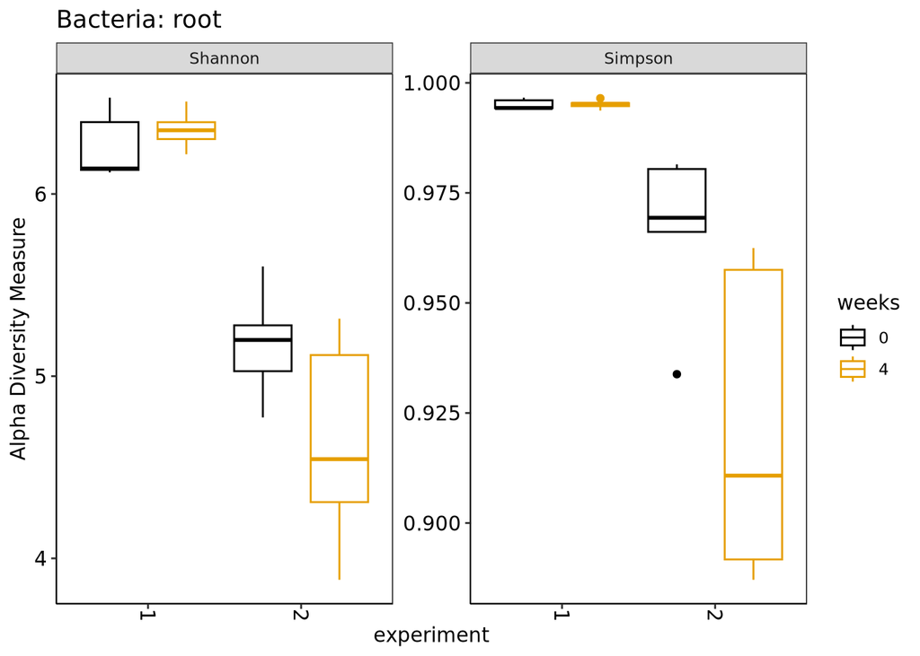

```r
ggsave(filename = "alpha_BAC_root_exp.png", path = FIGURES_DIR)

# Soil bacteria

alpha_BAC_soil_exp <- plot_alpha(
  BAC_exp$soil$countData, BAC_exp$soil$colData,
  design = "experiment", colour = "weeks",
  measures = measures,
  type = "box"
) + scale_colour_manual(values = cbPalette) +
  # theme(axis.title.x = element_blank()) +
  ggtitle("Bacteria: root")
alpha_BAC_root_exp
```

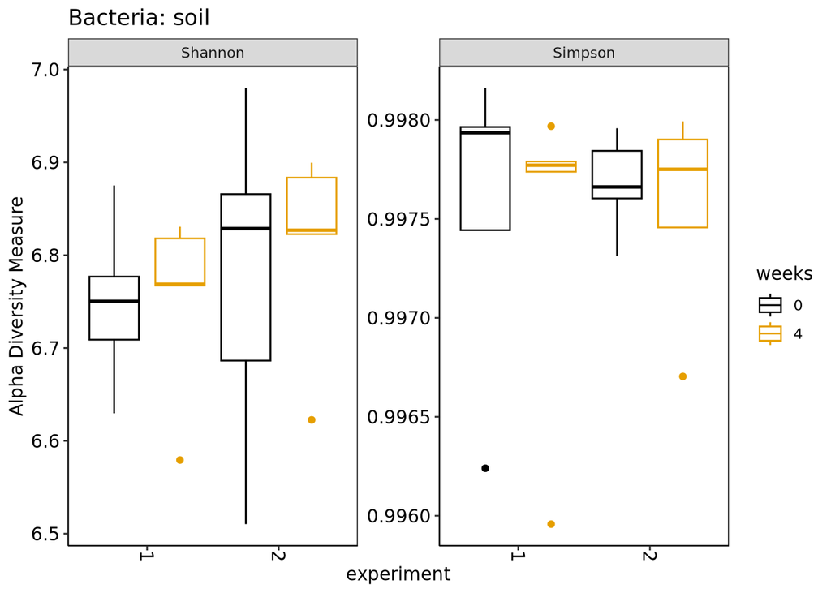

```r
ggsave(filename = "alpha_BAC_root_exp.png", path = FIGURES_DIR)

# Soil bacteria

alpha_BAC_soil_exp <- plot_alpha(
  BAC_exp$soil$countData, BAC_exp$soil$colData,
  design = "experiment", colour = "weeks",
  measures = measures,
  type = "box"
) + scale_colour_manual(values = cbPalette) +
  # theme(axis.title.x = element_blank()) +
  ggtitle("Bacteria: soil")
alpha_BAC_soil_exp
```

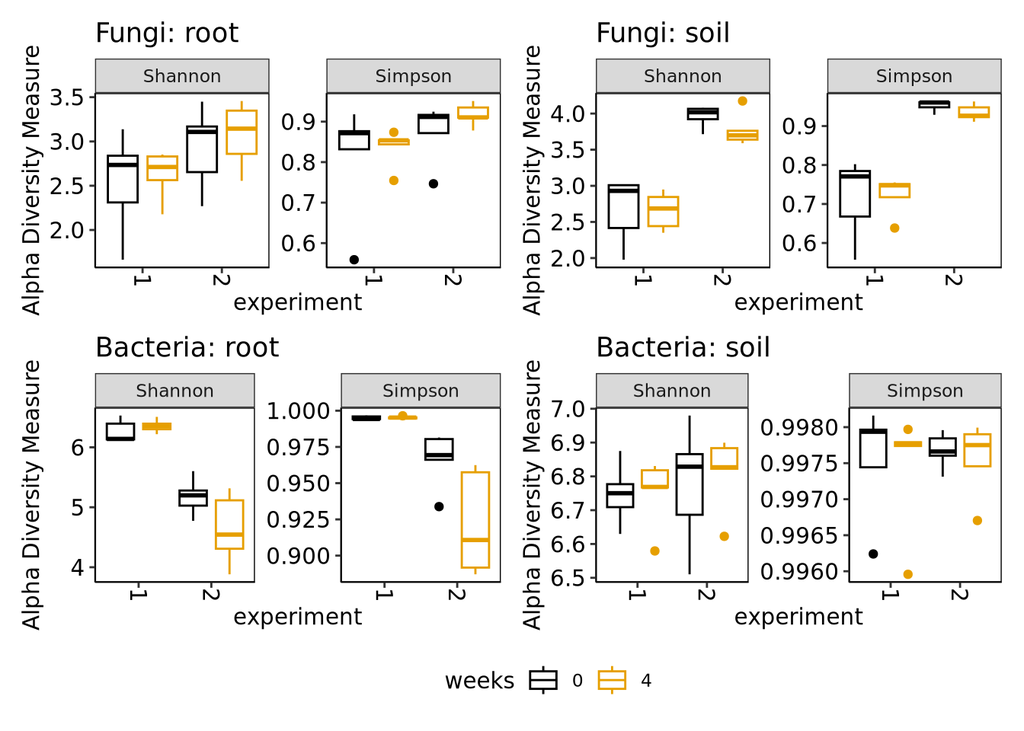

```r
ggsave(filename = "alpha_BAC_soil_exp.png", path = FIGURES_DIR)

# alpha_exp_combined <- ggarrange(
#   list(
#     alpha_FUN_root_exp, alpha_FUN_soil_exp,
#     alpha_BAC_root_exp, alpha_BAC_soil_exp
#   ),
#   ncol = 2, nrow = 2,
#   labels = c("Fungi Root", "Fungi Soil", "Bacteria Root", "Bacteria Soil"),
#   common.legend = TRUE, legend = "bottom"
# )

alpha_exp_combined <- (
  alpha_FUN_root_exp + alpha_FUN_soil_exp
) / (
  alpha_BAC_root_exp + alpha_BAC_soil_exp
) +
  plot_layout(guides = "collect") & # Collect legends into a single common legend
  theme(legend.position = "bottom") # Position the common legend


alpha_exp_combined
```

```r
ggsave(
  filename = "alpha_exp_combined.png", plot = alpha_exp_combined, path = FIGURES_DIR
  # width = 10, height = 10, units = "cm"
)
```

### 9.2 Permutation ANOVA on alpha diversity index ranks

```r
# Alpha diversity data

fun_alpha <- plot_alpha(FUN$countData, FUN$colData, returnData = TRUE)
bac_alpha <- plot_alpha(BAC$countData, BAC$colData, returnData = TRUE)

# Join with metadata
fun_alpha <- fun_alpha[as.data.table(FUN$colData, keep.rownames = "Samples"), on = "Samples"]
bac_alpha <- bac_alpha[as.data.table(BAC$colData, keep.rownames = "Samples"), on = "Samples"]

combined_alpha <- rbind(
  fun_alpha[, Type := "Fungi"],
  bac_alpha[, Type := "Bacteria"]
)

# fun_alpha <-

# Full model
formula <- metric ~ treatment + timepoint + treatment:timepoint + experiment + treatment:experiment + (year + 1 | plot / experiment) + (1 | block / experiment)

# Timepoint model for E1
formula_t <- metric ~ treatment * timepoint + (1 | plot) + (1 | block)

# formula_t <- metric ~ treatment * timepoint + (1 | block / plot)

# Experiment model without timepoint 2
formula_e <- metric ~ treatment * experiment + (1 | block / experiment)


alpha_anova <- function(data, formula, metrics, nperm = 1000) {
  sources <- unique(data$source)
  for (src in sources) {
    data_src <- data[source == src]
    for (met in metrics) {
      data_src[, metric := rank(data_src[[met]])]
      cat("\n", src, ":", met, "\n", sep = "")
      res <- perm.lmer(formula, data_src, type = "anova", nperm = nperm)
      print(res)
    }
  }
}


metrics <- c("S.chao1", "shannon", "simpson")

# Fungi

alpha_anova(
  fun_alpha, formula, metrics, nperm = 1000
)

# Bacteria

alpha_anova(
  bac_alpha, formula, metrics, nperm = 1000
)
```

## 10 Beta diversity

### 10.1 Bray-Curtis

#### 10.1.1 ADONIS

```r
e_design <- vg ~ treatment * experiment + experiment:block

t_design <- vg ~ treatment * timepoint

adonis_analysis <- function(data, name, source, design, strata = NULL, nperm = 1000) {
  cat("\n", name, ":", source, "\n")
  set.seed(SEED)
  vg <- vegdist(t(counts(data$dds, normalize = T)), method = "bray")
  adonis2(
    update(design, vg ~ .),
    data$colData,
    strata = if (!is.null(strata)) data$colData[[strata]] else NULL,
    # strata = colData(dds)$experiment:colData(dds)$block, # For repeat measures
    permutations = nperm,
    by = "terms"
  )
}


# Apply adonis analysis to each subset of data
apply_to_subsets(FUN_exp, adonis_analysis, "Fungi Experiment", e_design)
```

```
##
##  Fungi Experiment : root
##
##  Fungi Experiment : soil
```

```
## $root
## Permutation test for adonis under reduced model
## Terms added sequentially (first to last)
## Permutation: free
## Number of permutations: 1000
##
## adonis2(formula = update(design, vg ~ .), data = data$colData, permutations = nperm, by = "terms", strata = if (!is.null(strata)) data$colData[[strata]] else NULL)
##                      Df SumOfSqs      R2      F   Pr(>F)
## treatment             1   0.5174 0.06235 1.4210 0.042957 *
## experiment            1   0.9725 0.11720 2.6712 0.000999 ***
## treatment:experiment  1   0.5436 0.06551 1.4931 0.016983 *
## experiment:block      8   3.3518 0.40393 1.1508 0.078921 .
## Residual              8   2.9127 0.35101
## Total                19   8.2980 1.00000
## ---
## Signif. codes:  0 '***' 0.001 '**' 0.01 '*' 0.05 '.' 0.1 ' ' 1
##
## $soil
## Permutation test for adonis under reduced model
## Terms added sequentially (first to last)
## Permutation: free
## Number of permutations: 1000
##
## adonis2(formula = update(design, vg ~ .), data = data$colData, permutations = nperm, by = "terms", strata = if (!is.null(strata)) data$colData[[strata]] else NULL)
##                      Df SumOfSqs      R2      F   Pr(>F)
## treatment             1   0.3332 0.04612 1.2387 0.173826
## experiment            1   1.5968 0.22101 5.9365 0.000999 ***
## treatment:experiment  1   0.2896 0.04008 1.0765 0.312687
## experiment:block      8   2.8537 0.39496 1.3261 0.026973 *
## Residual              8   2.1519 0.29783
## Total                19   7.2252 1.00000
## ---
## Signif. codes:  0 '***' 0.001 '**' 0.01 '*' 0.05 '.' 0.1 ' ' 1
```

```r
apply_to_subsets(BAC_exp, adonis_analysis, "Bacteria Experiment", e_design)
```

```
##
##  Bacteria Experiment : root
##
##  Bacteria Experiment : soil
```

```
## $root
## Permutation test for adonis under reduced model
## Terms added sequentially (first to last)
## Permutation: free
## Number of permutations: 1000
##
## adonis2(formula = update(design, vg ~ .), data = data$colData, permutations = nperm, by = "terms", strata = if (!is.null(strata)) data$colData[[strata]] else NULL)
##                      Df SumOfSqs      R2      F   Pr(>F)
## treatment             1   0.1670 0.03975 1.0896 0.322677
## experiment            1   1.5145 0.36054 9.8825 0.000999 ***
## treatment:experiment  1   0.1149 0.02735 0.7497 0.630370
## experiment:block      8   1.1783 0.28049 0.9611 0.552448
## Residual              8   1.2260 0.29186
## Total                19   4.2007 1.00000
## ---
## Signif. codes:  0 '***' 0.001 '**' 0.01 '*' 0.05 '.' 0.1 ' ' 1
##
## $soil
## Permutation test for adonis under reduced model
## Terms added sequentially (first to last)
## Permutation: free
## Number of permutations: 1000
##
## adonis2(formula = update(design, vg ~ .), data = data$colData, permutations = nperm, by = "terms", strata = if (!is.null(strata)) data$colData[[strata]] else NULL)
##                      Df SumOfSqs      R2       F   Pr(>F)
## treatment             1   0.1022 0.02591  1.1057 0.298701
## experiment            1   2.2068 0.55938 23.8745 0.000999 ***
## treatment:experiment  1   0.0749 0.01899  0.8105 0.473526
## experiment:block      8   0.8217 0.20829  1.1112 0.420579
## Residual              8   0.7395 0.18744
## Total                19   3.9452 1.00000
## ---
## Signif. codes:  0 '***' 0.001 '**' 0.01 '*' 0.05 '.' 0.1 ' ' 1
```

```r
apply_to_subsets(FUN_time, adonis_analysis, "Fungi Timepoint", t_design, "plot")
```

```
##
##  Fungi Timepoint : root
```

```
##
##  Fungi Timepoint : soil
```

```
## $root
## Permutation test for adonis under reduced model
## Terms added sequentially (first to last)
## Blocks:  strata
## Permutation: free
## Number of permutations: 1023
##
## adonis2(formula = update(design, vg ~ .), data = data$colData, permutations = nperm, by = "terms", strata = if (!is.null(strata)) data$colData[[strata]] else NULL)
##                     Df SumOfSqs      R2      F   Pr(>F)
## treatment            1   0.4050 0.04844 0.9502 0.022977 *
## timepoint            1   0.6716 0.08034 1.5759 0.004995 **
## treatment:timepoint  1   0.4639 0.05550 1.0885 0.327672
## Residual            16   6.8191 0.81572
## Total               19   8.3596 1.00000
## ---
## Signif. codes:  0 '***' 0.001 '**' 0.01 '*' 0.05 '.' 0.1 ' ' 1
##
## $soil
## Permutation test for adonis under reduced model
## Terms added sequentially (first to last)
## Blocks:  strata
## Permutation: free
## Number of permutations: 1023
##
## adonis2(formula = update(design, vg ~ .), data = data$colData, permutations = nperm, by = "terms", strata = if (!is.null(strata)) data$colData[[strata]] else NULL)
##                     Df SumOfSqs      R2      F   Pr(>F)
## treatment            1   0.3293 0.04452 0.9126 0.003996 **
## timepoint            1   0.9651 0.13048 2.6749 0.001998 **
## treatment:timepoint  1   0.3293 0.04452 0.9127 0.663337
## Residual            16   5.7729 0.78048
## Total               19   7.3966 1.00000
## ---
## Signif. codes:  0 '***' 0.001 '**' 0.01 '*' 0.05 '.' 0.1 ' ' 1
```

```r
apply_to_subsets(BAC_time, adonis_analysis, "Bacteria Timepoint", t_design, "plot")
```

```
##
##  Bacteria Timepoint : root
```

```
##
##  Bacteria Timepoint : soil
```

```
## $root
## Permutation test for adonis under reduced model
## Terms added sequentially (first to last)
## Blocks:  strata
## Permutation: free
## Number of permutations: 1023
##
## adonis2(formula = update(design, vg ~ .), data = data$colData, permutations = nperm, by = "terms", strata = if (!is.null(strata)) data$colData[[strata]] else NULL)
##                     Df SumOfSqs      R2      F   Pr(>F)
## treatment            1   0.2168 0.05845 1.6051 0.003996 **
## timepoint            1   1.1825 0.31882 8.7550 0.001998 **
## treatment:timepoint  1   0.1486 0.04007 1.1003 0.400599
## Residual            16   2.1611 0.58266
## Total               19   3.7090 1.00000
## ---
## Signif. codes:  0 '***' 0.001 '**' 0.01 '*' 0.05 '.' 0.1 ' ' 1
##
## $soil
## Permutation test for adonis under reduced model
## Terms added sequentially (first to last)
## Blocks:  strata
## Permutation: free
## Number of permutations: 1023
##
## adonis2(formula = update(design, vg ~ .), data = data$colData, permutations = nperm, by = "terms", strata = if (!is.null(strata)) data$colData[[strata]] else NULL)
##                     Df SumOfSqs      R2       F   Pr(>F)
## treatment            1  0.11353 0.04102  1.1842 0.003996 **
## timepoint            1  1.00454 0.36298 10.4784 0.001998 **
## treatment:timepoint  1  0.11556 0.04176  1.2054 0.385614
## Residual            16  1.53389 0.55425
## Total               19  2.76752 1.00000
## ---
## Signif. codes:  0 '***' 0.001 '**' 0.01 '*' 0.05 '.' 0.1 ' ' 1
```

```r
# df <- result %>% data.frame()
# df$Perc.Var <- df$SumOfSqs / df["Total", "SumOfSqs"] * 100
# df %>%
#   kbl() %>%
#   kable_styling("striped", full_width = F)
```

#### 10.1.2 NMDS

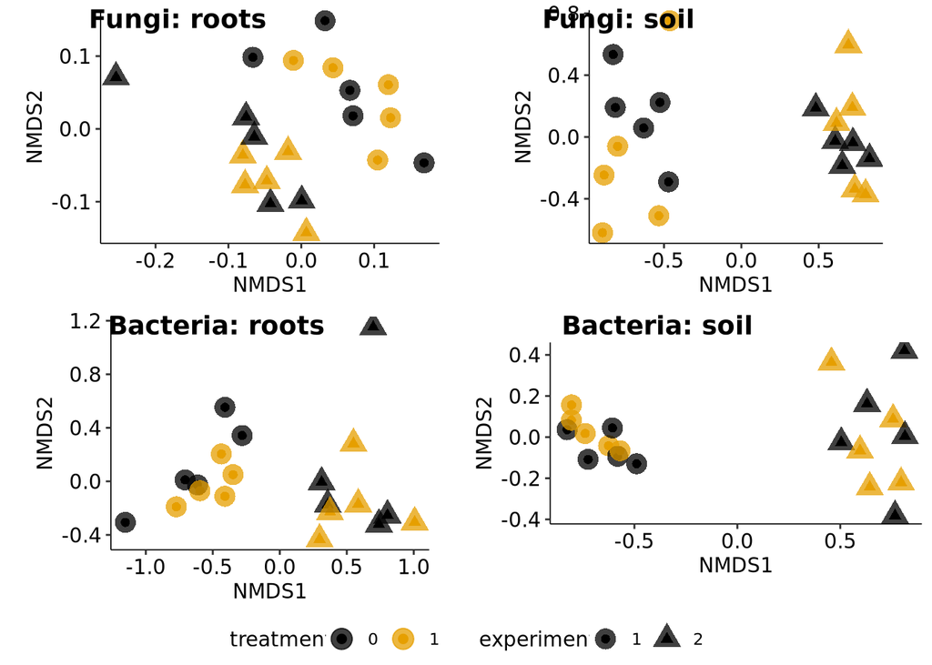

```r
set.seed(SEED)

#' @title NMDS plot
#' @description Create a NMDS plot for a given DESeq2 object
#' @param dds DESeq2 object
#' @param shape A string representing factor to use for the shape aesthetic
#' @param filename A string representing the filename to save the plot
#' @return A ggplot object of the NMDS plot
#'
nmdsPlot <- function(dds, shape, filename) {
  vg <- vegdist(t(counts(dds, normalize = T)), method = "bray")
  ord <- metaMDS(vg, trace=0)

  plot <- plotOrd(
    scores(ord),
    colData(dds),
    design = "treatment",
    shape = shape,
    alpha = 0.75, cbPalette = T
  )
  ggsave(filename, path = FIGURES_DIR)
  return(plot)
}

# Experiment

nmds_exp_fun_root <- nmdsPlot(FUN_exp$root$dds, shape = "experiment", filename = "NMDS_FUN_root_exp.png")
nmds_exp_fun_soil <- nmdsPlot(FUN_exp$soil$dds, shape = "experiment", filename = "NMDS_FUN_soil_exp.png")
nmds_exp_bac_root <- nmdsPlot(BAC_exp$root$dds, shape = "experiment", filename = "NMDS_BAC_root_exp.png")
nmds_exp_bac_soil <- nmdsPlot(BAC_exp$soil$dds, shape = "experiment", filename = "NMDS_BAC_soil_exp.png")

nmds_exp_combined <- ggarrange(
  plotlist = list(nmds_exp_fun_root, nmds_exp_fun_soil, nmds_exp_bac_root, nmds_exp_bac_soil),
  common.legend = TRUE,
  legend = "bottom",
  labels = c("Fungi: roots", "Fungi: soil", "Bacteria: roots", "Bacteria: soil")
)
nmds_exp_combined
```

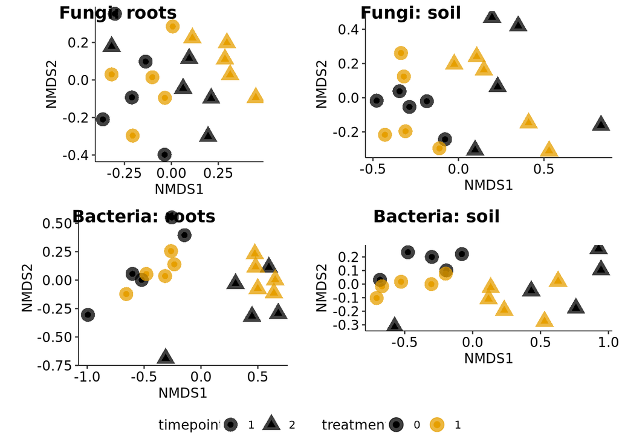

```r
ggsave("NMDS_exp.png", plot = nmds_exp_combined, path = FIGURES_DIR)

# Timepoint

nmds_time_fun_root <- nmdsPlot(FUN_time$root$dds, shape = "timepoint", filename = "NMDS_FUN_root_time.png")
nmds_time_fun_soil <- nmdsPlot(FUN_time$soil$dds, shape = "timepoint", filename = "NMDS_FUN_soil_time.png")
nmds_time_bac_root <- nmdsPlot(BAC_time$root$dds, shape = "timepoint", filename = "NMDS_BAC_root_time.png")
nmds_time_bac_soil <- nmdsPlot(BAC_time$soil$dds, shape = "timepoint", filename = "NMDS_BAC_soil_time.png")

nmds_time_combined <- ggarrange(
  plotlist = list(nmds_time_fun_root, nmds_time_fun_soil, nmds_time_bac_root, nmds_time_bac_soil),
  common.legend = TRUE,
  legend = "bottom",
  labels = c("Fungi: roots", "Fungi: soil", "Bacteria: roots", "Bacteria: soil")
)
nmds_time_combined
```

```r
ggsave("NMDS_time.png", plot = nmds_time_combined, path = FIGURES_DIR)
```